# Explore_bikeshare_data

### Explore Bike Share Data

For this project, your goal is to ask and answer three questions about the available bikeshare data from Washington, Chicago, and New York. This notebook can be submitted directly through the workspace when you are confident in your results.

You will be graded against the project [Rubric](https://review.udacity.com/#!/rubrics/2508/view) by a mentor after you have submitted. To get you started, you can use the template below, but feel free to be creative in your solutions!

```r
# Import libraries; will produce output about "The following object is masked from 'package:{name}'"; rerun cell
# to remove output
library(ggplot2)
library(lubridate)
library(hms)
library(dplyr)
```

```r
# Import data
ny = read.csv('new_york_city.csv')
wash = read.csv('washington.csv')
chi = read.csv('chicago.csv')
```

```r
head(ny)
```

| X | Start.Time | End.Time | Trip.Duration | Start.Station | End.Station | User.Type | Gender | Birth.Year |
| --- | --- | --- | --- | --- | --- | --- | --- | --- |
| 5688089 | 2017-06-11 14:55:05 | 2017-06-11 15:08:21 | 795 | Suffolk St & Stanton St | W Broadway & Spring St | Subscriber | Male | 1998 |
| 4096714 | 2017-05-11 15:30:11 | 2017-05-11 15:41:43 | 692 | Lexington Ave & E 63 St | 1 Ave & E 78 St | Subscriber | Male | 1981 |
| 2173887 | 2017-03-29 13:26:26 | 2017-03-29 13:48:31 | 1325 | 1 Pl & Clinton St | Henry St & Degraw St | Subscriber | Male | 1987 |
| 3945638 | 2017-05-08 19:47:18 | 2017-05-08 19:59:01 | 703 | Barrow St & Hudson St | W 20 St & 8 Ave | Subscriber | Female | 1986 |
| 6208972 | 2017-06-21 07:49:16 | 2017-06-21 07:54:46 | 329 | 1 Ave & E 44 St | E 53 St & 3 Ave | Subscriber | Male | 1992 |
| 1285652 | 2017-02-22 18:55:24 | 2017-02-22 19:12:03 | 998 | State St & Smith St | Bond St & Fulton St | Subscriber | Male | 1986 |

```r
head(wash)
```

| X | Start.Time | End.Time | Trip.Duration | Start.Station | End.Station | User.Type |
| --- | --- | --- | --- | --- | --- | --- |
| 1621326 | 2017-06-21 08:36:34 | 2017-06-21 08:44:43 | 489.066 | 14th & Belmont St NW | 15th & K St NW | Subscriber |
| 482740 | 2017-03-11 10:40:00 | 2017-03-11 10:46:00 | 402.549 | Yuma St & Tenley Circle NW | Connecticut Ave & Yuma St NW | Subscriber |
| 1330037 | 2017-05-30 01:02:59 | 2017-05-30 01:13:37 | 637.251 | 17th St & Massachusetts Ave NW | 5th & K St NW | Subscriber |
| 665458 | 2017-04-02 07:48:35 | 2017-04-02 08:19:03 | 1827.341 | Constitution Ave & 2nd St NW/DOL | M St & Pennsylvania Ave NW | Customer |
| 1481135 | 2017-06-10 08:36:28 | 2017-06-10 09:02:17 | 1549.427 | Henry Bacon Dr & Lincoln Memorial Circle NW | Maine Ave & 7th St SW | Subscriber |
| 1148202 | 2017-05-14 07:18:18 | 2017-05-14 07:24:56 | 398.000 | 1st & K St SE | Eastern Market Metro / Pennsylvania Ave & 7th St SE | Subscriber |

```r
head(chi)
```

| X | Start.Time | End.Time | Trip.Duration | Start.Station | End.Station | User.Type | Gender | Birth.Year |
| --- | --- | --- | --- | --- | --- | --- | --- | --- |
| 1423854 | 2017-06-23 15:09:32 | 2017-06-23 15:14:53 | 321 | Wood St & Hubbard St | Damen Ave & Chicago Ave | Subscriber | Male | 1992 |
| 955915 | 2017-05-25 18:19:03 | 2017-05-25 18:45:53 | 1610 | Theater on the Lake | Sheffield Ave & Waveland Ave | Subscriber | Female | 1992 |
| 9031 | 2017-01-04 08:27:49 | 2017-01-04 08:34:45 | 416 | May St & Taylor St | Wood St & Taylor St | Subscriber | Male | 1981 |
| 304487 | 2017-03-06 13:49:38 | 2017-03-06 13:55:28 | 350 | Christiana Ave & Lawrence Ave | St. Louis Ave & Balmoral Ave | Subscriber | Male | 1986 |
| 45207 | 2017-01-17 14:53:07 | 2017-01-17 15:02:01 | 534 | Clark St & Randolph St | Desplaines St & Jackson Blvd | Subscriber | Male | 1975 |
| 1473887 | 2017-06-26 09:01:20 | 2017-06-26 09:11:06 | 586 | Clinton St & Washington Blvd | Canal St & Taylor St | Subscriber | Male | 1990 |

### Question 1

**What are the most popular times for people to ride bikes?**

The following cell takes the hour and minute data from the Start.Time column for each table and converts stores it as a decimal number (5:30pm turns to 17.5). This is done to convert the time data from discrete to continuous for use in visualizations. The Start.Time column in the Washington table outputs an error stating that the format of the column is ambiguous; using lubridate's `ymd_hms()` function tells the `as.POSIXct()` function what format the column is in; none of the other tables needed this.

```r
# Create function to take Start.Time column and return decimal value for time
format_start_time <- function(data) {
    return (as.numeric(format(as.POSIXct(ymd_hms(data$Start.Time)), '%H')) +
            (as.numeric(format(as.POSIXct(ymd_hms(data$Start.Time)), '%M'))/60))
}
```

```r
# Call format_start_time() on each table and set to 'start' column
ny$start <- format_start_time(ny)

wash$start <- format_start_time(wash)

chi$start <- format_start_time(chi)
```

```r
head(ny)
```

| X | Start.Time | End.Time | Trip.Duration | Start.Station | End.Station | User.Type | Gender | Birth.Year | start |
| --- | --- | --- | --- | --- | --- | --- | --- | --- | --- |
| 5688089 | 2017-06-11 14:55:05 | 2017-06-11 15:08:21 | 795 | Suffolk St & Stanton St | W Broadway & Spring St | Subscriber | Male | 1998 | 14.916667 |
| 4096714 | 2017-05-11 15:30:11 | 2017-05-11 15:41:43 | 692 | Lexington Ave & E 63 St | 1 Ave & E 78 St | Subscriber | Male | 1981 | 15.500000 |
| 2173887 | 2017-03-29 13:26:26 | 2017-03-29 13:48:31 | 1325 | 1 Pl & Clinton St | Henry St & Degraw St | Subscriber | Male | 1987 | 13.433333 |
| 3945638 | 2017-05-08 19:47:18 | 2017-05-08 19:59:01 | 703 | Barrow St & Hudson St | W 20 St & 8 Ave | Subscriber | Female | 1986 | 19.783333 |
| 6208972 | 2017-06-21 07:49:16 | 2017-06-21 07:54:46 | 329 | 1 Ave & E 44 St | E 53 St & 3 Ave | Subscriber | Male | 1992 | 7.816667 |
| 1285652 | 2017-02-22 18:55:24 | 2017-02-22 19:12:03 | 998 | State St & Smith St | Bond St & Fulton St | Subscriber | Male | 1986 | 18.916667 |

```r
# Set graph size
options(repr.plot.width=8, repr.plot.height=4)
```

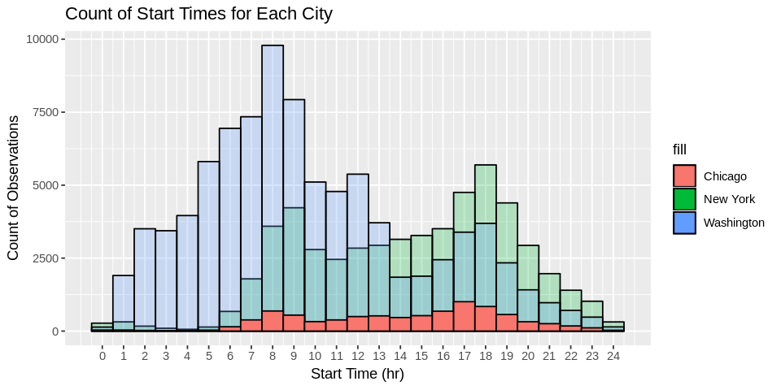

```r
# Layered histogram for 'start' time for each city with bin size equal to 1 hour
ggplot(aes(x=start), data=NULL) +
    geom_histogram(binwidth=1, color=I('black'), aes(fill='New York'), alpha=0.25, data=ny, na.rm=TRUE) +
    geom_histogram(binwidth=1, color=I('black'), aes(fill='Washington'), alpha=0.25, data=wash, na.rm=TRUE) +
    geom_histogram(binwidth=1, color=I('black'), aes(fill='Chicago'), alpha=1, data=chi, na.rm=TRUE) +
    scale_x_continuous(breaks=seq(0, 24, 1)) +
    labs(x='Start Time (hr)', y='Count of Observations', title='Count of Start Times for Each City')
```

```r
# Source - https://stackoverflow.com/a/8189441
# Posted by Ken Williams, modified by community. See post 'Timeline' for change history
# Retrieved 2026-06-03, License - CC BY-SA 4.0

Mode <- function(x) {
  ux <- unique(x)
  ux[which.max(tabulate(match(x, ux)))]
}
```

```r
Mode(ny$start)
Mode(wash$start)
Mode(chi$start)
```

17.1333333333333

8.31666666666667

17.2

> The modes for the New York and Chicago datasets are just after 5:00pm, while the mode for Washington, DC is around 8:20am.

Notably, the Washington dataset has more data than the other two, and the Chicago dataset has significantly less than the other two.

```r
# Show size of each dataset
cat('New York dataset: ', dim(ny))
cat('\nChicago dataset: ', dim(chi))
cat('\nWashington dataset: ', dim(wash))
```

```
New York dataset:  54770 10
Chicago dataset:  8630 10
Washington dataset:  89051 8
```

```r
# In preparation to merge datasets, add 'city' column
ny$city <- 'New York'
wash$city <- 'Washington'
chi$city <- 'Chicago'
```

```r
# Merge tables into one
# The 'wash' table doesn't contain certain columns, one of which will be used later, so two.cities and three.cities
# are created. This is also easier than merging all three tables in one line
two.cities <- merge(ny, chi, all=TRUE)
three.cities <- merge(two.cities, wash, all=TRUE)
```

```r
dim(three.cities)
```

1. 152451

2. 11

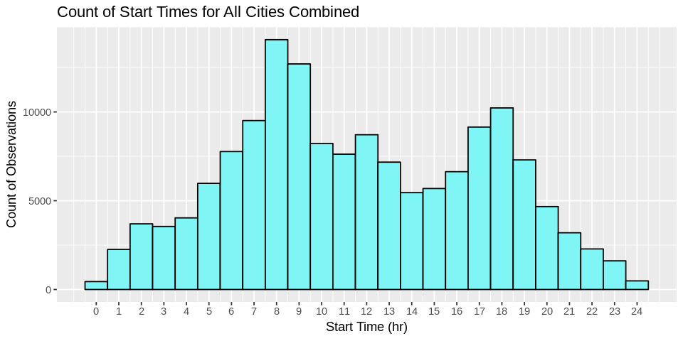

```r
# Plot the same information as above (histogram of start time), but with merged dataset
ggplot(aes(start), data=three.cities) +
    geom_histogram(binwidth=1, color=I('black'), fill=I('#7FF5F5'), na.rm=TRUE) +
    scale_x_continuous(breaks=seq(0, 24, 1)) +
    labs(x='Start Time (hr)', y='Count of Observations', title='Count of Start Times for All Cities Combined')
```

```r
Mode(three.cities$start)
```

8.48333333333333

It seems that, generally speaking, 8-9 AM and 5-6 PM are the most popular times to start riding a bike in all three cities, though Washington seems to prefer the morning, while Chicago and New York prefer the afternoon; the preference for one time of day seems larger for Washington, and the other two are more evenly distributed. When combined, this trend is still appearent.  
This trend makes a lot of sense, as very few people are likely biking during the night, and noon is typically reserved for mealtime, with the next few hours normally for relaxing during the weekend or work during weekdays. Thus the most popular times are after breakfast or before work, and after dinner or after work.

### Question 2

**What correlation, if any, is there between age and riding duration?**

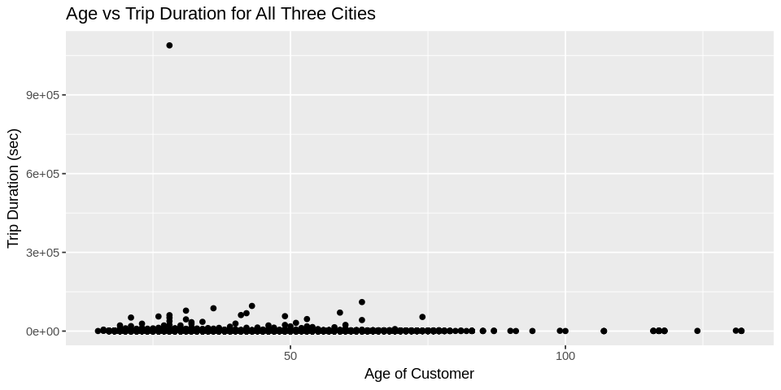

```r
# Plot scatter graph for age and trip duration; age column does not exist, but since the dataset is from 2017,
# subtracting birth year from 2017 gives the age of the individual
ggplot(aes(x=2017-Birth.Year, y=Trip.Duration), data=three.cities) +
    geom_point(, na.rm=TRUE) +
    labs(x='Age of Customer', y='Trip Duration (sec)', title='Age vs Trip Duration for All Three Cities')
```

```r
# Check information on trip duration and birth year
summary(two.cities$Trip.Duration)
summary(two.cities$Birth.Year)
```

```
     Min.   1st Qu.    Median      Mean   3rd Qu.      Max.      NA's
     60.0     371.0     617.0     908.2    1060.0 1088634.0         1
```

```
   Min. 1st Qu.  Median    Mean 3rd Qu.    Max.    NA's
   1885    1970    1981    1979    1988    2002    6965
```

> There's a bit to unpack here. A quick Google search reveals that the current record for the oldest person is 122 years old. Since this data is from 2017, the oldest person in this dataset is 2017-1885, or 132 years old, and someone out there had a bike for a little over 12.5 days. Let's try this again with more reasonable numbers.

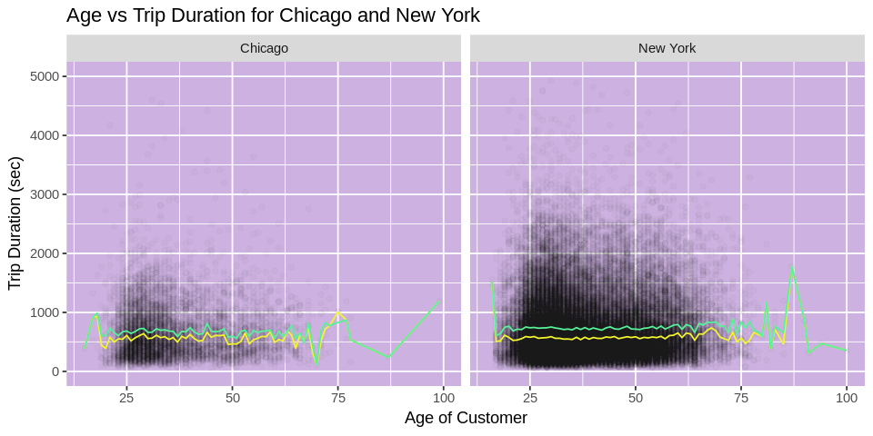

```r
# Create separate scatter plots for age vs trip duration for Chicago and New York; add line graphs for mean and
# median trip duration per age

# Washington dataset does not have Birth.Year column, so two.cities is used
ggplot(aes(x=2017-Birth.Year, y=Trip.Duration), data=two.cities) +
    geom_point(alpha=0.02, na.rm=TRUE) +
    geom_line(stat='summary', fun.y='median', color=I('#F2F52C'), na.rm=TRUE) +
    geom_line(stat='summary', fun.y='mean', color=I('#55F298'), na.rm=TRUE) +
    scale_y_continuous(limits=c(0,5000)) +
    scale_x_continuous(limits=c(15,100)) +
    facet_wrap(~city) +
    theme(panel.background = element_rect(fill=I('#CDB1E0'))) +
    labs(x='Age of Customer', y='Trip Duration (sec)', title='Age vs Trip Duration for Chicago and New York')
```

Generally speaking, bike riders are mostly younger than 75. Looking at the scatter plot, the maximum of the densest part decreases as age increases from 25 to around 63, but the median and mean don't really show any discernable trend. In conclusion, there does not seem to be any significant correlation between age and riding duration.

### Question 3

**How much more, if at all, do subscribers ride bikes than non-subscribers?**  
*The dataset has two values for User.Type: subscriber or customer*

```r
# User.Type actually has three values: 'Subscriber', 'Customer', and '', which is distinct from NA or NUll
head(subset(three.cities, User.Type == ''))
```

|  | X | Start.Time | End.Time | Trip.Duration | Start.Station | End.Station | User.Type | start | city | Gender | Birth.Year |
| --- | --- | --- | --- | --- | --- | --- | --- | --- | --- | --- | --- |
| 12 | 132 |  |  | NA |  |  |  | NA | Washington | NA | NA |
| 308 | 4371 | 2017-01-01 12:29:20 | 2017-01-01 12:45:38 | 977 | 1 Ave & E 44 St | Grand Army Plaza & Central Park S |  | 12.48333 | New York | Male | 1992 |
| 676 | 9893 | 2017-01-01 15:51:30 | 2017-01-01 16:05:15 | 824 | Pier 40 - Hudson River Park | Washington St & Gansevoort St |  | 15.85000 | New York |  | 1983 |
| 793 | 11593 | 2017-01-01 17:04:30 | 2017-01-01 17:19:59 | 928 | 11 Ave & W 27 St | Bank St & Hudson St |  | 17.06667 | New York | Male | 1983 |
| 1392 | 20990 | 2017-01-02 14:40:49 | 2017-01-02 14:53:52 | 782 | Clinton St & Joralemon St | Hanson Pl & Ashland Pl |  | 14.66667 | New York | Male | 1996 |
| 1423 | 21286 | 2017-01-02 15:20:03 | 2017-01-02 15:39:11 | 1147 | Peck Slip & Front St | Madison St & Montgomery St |  | 15.33333 | New York | Female | 1988 |

```r
# Remove rows from three.cities where User.Type is an empty string
three.cities <- subset(three.cities, User.Type != '')
```

```r
# Still generates extra row with NULL; unsure of how to fix this
by(three.cities$Trip.Duration, three.cities$User.Type, summary)
```

```
three.cities$User.Type:
NULL
------------------------------------------------------------
three.cities$User.Type: Customer
     Min.   1st Qu.    Median      Mean   3rd Qu.      Max.
     61.3     915.4    1450.0    2514.7    2404.5 1088634.0
------------------------------------------------------------
three.cities$User.Type: Subscriber
    Min.  1st Qu.   Median     Mean  3rd Qu.     Max.
    60.0    352.2    567.5    739.5    914.7 170032.9
```

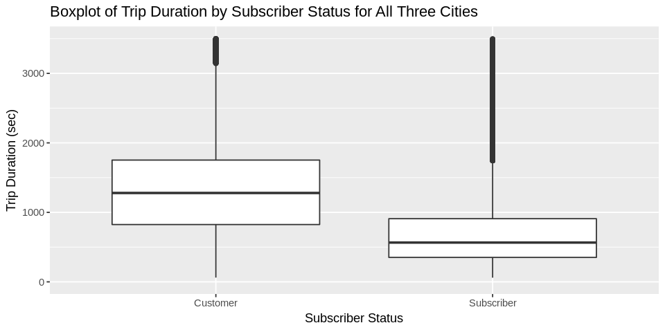

```r
# Create boxplot of trip duration based on User.Type
ggplot(data=three.cities, aes(x=User.Type, y=Trip.Duration)) +
    geom_boxplot(na.rm=TRUE) +
    scale_y_continuous(limits=c(0,3500)) +
    labs(x='Subscriber Status', y='Trip Duration (sec)',
         title='Boxplot of Trip Duration by Subscriber Status for All Three Cities')
```

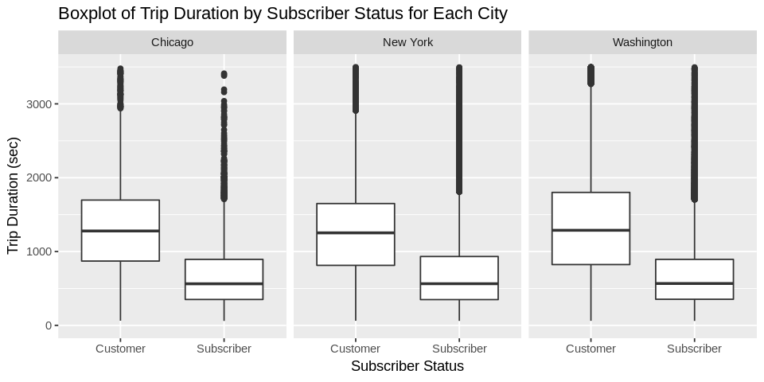

```r
# Same as above, separated by city
ggplot(data=three.cities, aes(x=User.Type, y=Trip.Duration)) +
    geom_boxplot(na.rm=TRUE) +
    scale_y_continuous(limits=c(0,3500)) +
    facet_wrap(~city) +
    labs(x='Subscriber Status', y='Trip Duration (sec)',
         title='Boxplot of Trip Duration by Subscriber Status for Each City')
```

```r
# Show count by User.Type
three.cities %>%
    count(User.Type)
```

| User.Type | n |
| --- | --- |
| Customer | 30754 |
| Subscriber | 121576 |

Chicago's [Divvy](https://divvybikes.com/) has a few subscriber plans and one non-subscriber option. The non-sub option has a $\$$1 payment followed by $\$$0.20 per minute, while the subscriber plans offer three hours of free riding for $\$$36 ($0.20*60*3=36$) worth of riding for $\$$19.90 for one day. There is also an annual plan which offers $\$$3,285 worth of bike rides per year for only $\$$143.90 per year.

In general, these prices incentivize longer rides for non-subscribers to avoid paying the extra dollar per ride, and more, but shorter, rides for subscribers to avoid paying directly for the time on the bike. This is, in fact, what we see. The count of subscribers is around 4 times the count of the non-subscribers, while the time spent riding is larger for non-subscribers.

## Finishing Up

> Congratulations! You have reached the end of the Explore Bikeshare Data Project. You should be very proud of all you have accomplished!

> **Tip**: Once you are satisfied with your work here, check over your report to make sure that it is satisfies all the areas of the [rubric](https://review.udacity.com/#!/rubrics/2508/view).

## Directions to Submit

> Before you submit your project, you need to create a .html or .pdf version of this notebook in the workspace here. To do that, run the code cell below. If it worked correctly, you should get a return code of 0, and you should see the generated .html file in the workspace directory (click on the orange Jupyter icon in the upper left).

> Alternatively, you can download this report as .html via the **File** > **Download as** submenu, and then manually upload it into the workspace directory by clicking on the orange Jupyter icon in the upper left, then using the Upload button.

> Once you've done this, you can submit your project by clicking on the "Submit Project" button in the lower right here. This will create and submit a zip file with this .ipynb doc and the .html or .pdf version you created. Congratulations!

```r
system('python -m nbconvert Explore_bikeshare_data.ipynb')
```